[figure not shown]

AB-46

Curtain Airbag Module

AIRBAG SYSTEM

8. Curtain Airbag Module

A: REMOVAL

CAUTION:

Refer to “CAUTION” of “General Description” before handling the airbag module. <Ref. to AB-9,

CAUTION, General Description.>

1) Turn the ignition switch to OFF.

2) Disconnect the ground cable from battery and wait for at least 60 seconds before starting work. <Ref. to

NT-5, BATTERY, NOTE, Note.>

NOTE:

• For models other than STI model, disconnect the ground terminal from battery sensor.

• On CVT models, shift the select lever into “D” before disconnecting the battery ground cable.

• For model with the power seat, move the seat to the front-most position before removing the battery

ground terminal.

3) Remove the trim panel - roof assembly. <Ref. to EI-99, REMOVAL, Roof Trim.>

4) Remove the curtain airbag module.

CAUTION:

• Be careful not to damage the curtain airbag module during removal.

• Never open the curtain airbag module before activation. Never reuse the deployed curtain airbag

module.

• Remove the modules in order starting from the vehicle front.

(1) Remove all the bolts and clips, and remove the curtain airbag module.

AB-03545

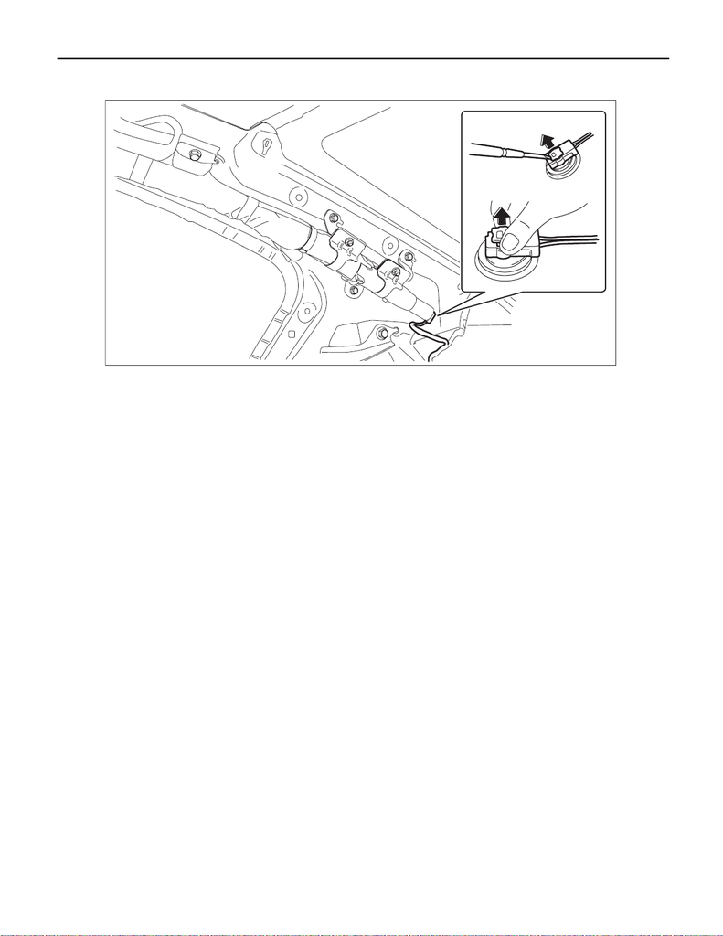

AB-47

Curtain Airbag Module

AIRBAG SYSTEM

(2) Disconnect the curtain airbag module connector. <Ref. to AB-19, DRIVER’S AIRBAG MODULE,

CURTAIN AIRBAG MODULE & PRETENSIONER, PROCEDURE, Airbag Connector.>

B: INSTALLATION

CAUTION:

• Refer to “CAUTION” of “General Description” before handling the airbag module. <Ref. to AB-9,

CAUTION, General Description.>

• When installing the curtain airbag module, install a specified part at specified place.

• Be careful not to damage the curtain airbag module during installation.

• Never open the curtain airbag module before activation. Never reuse the deployed curtain airbag

module.

• Make sure that there are no foreign matter on airbag module.

• When reusing the tether clip on the upper part of the trim panel - front pillar UPR, check that there is

no damage to the tether clip. If the clip is damaged, its holding force is reduced and the trim panel -

front pillar UPR may come off. Be sure to replace it with a new clip.

1) Before installation, inspect the following items and replace any faulty part with a new one.

• Airbag cover is scratched or torn.

• Harness and/or connector is cracked, deformed or open.

• Harness wire is exposed.

• Mounting bracket and securing clip are cracked or deformed.

2) Install the curtain airbag module.

CAUTION:

• Be sure to insert the connector in until it is locked.

• Press in the push lock securely. Then pull it gently to make sure that it is locked.

Tightening torque:

7.5 N·m (0.8 kgf-m, 5.5 ft-lb)

3) Install the trim panel - roof assembly. <Ref. to EI-102, INSTALLATION, Roof Trim.>

4) Connect the battery ground terminal. <Ref. to NT-5, BATTERY, NOTE, Note.>

NOTE:

For models other than STI model, connect the ground terminal to battery sensor.

AB-03556